# INFO_201_PS6

Jeffery Zhang

2023-11-27

## ———- PS6: Merging and Reshaping Data ———-

```r
library(readr)
```

```r
library(ggplot2)
library(dplyr)
library(tidyr)
library(viridis)
```

## ———- 1: How is CO2 related to global temperature? ———-

## ———- 1.1: Scripps CO2 Data ———-

## 1.1.1

```r
scripps_data <- read_delim("C:/Users/xuz-t/OneDrive/Documents/INFO_201_Scripts/PS6/data/scripps-co2.csv")
scripps_data <- scripps_data[, c("year", "month", "co2")]
head(scripps_data)
```

```
## # A tibble: 6 × 3
##    year month   co2
##   <dbl> <dbl> <dbl>
## 1  1958     1 -100.
## 2  1958     2 -100.
## 3  1958     3  316.
## 4  1958     4  317.
## 5  1958     5  318.
## 6  1958     6 -100.
```

## 1.1.2

A line in this dataframe represents the parts-per-million concentration of CO2 at the Mauna Loa Observatory, averaged across a given month.

## 1.1.3

A missing value is given by the value -99.99.

## 1.1.4

This data represents the period from 1958 to 2023.

## 1.1.5

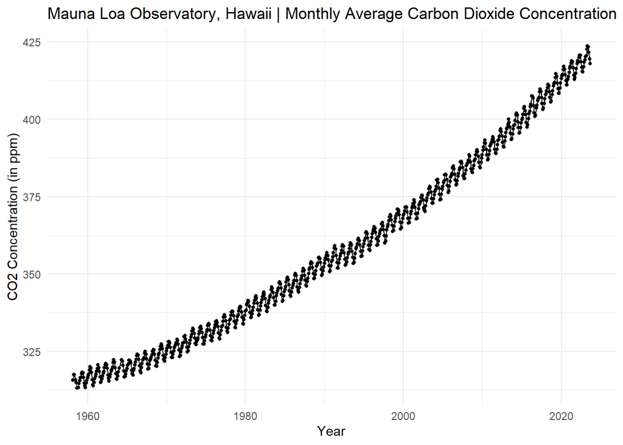

```r
filtered_scripps <- scripps_data %>%
  filter(co2 >= 0) %>%
  mutate(date = as.Date(paste(year, month, "01", sep = "-"), format = "%Y-%m-%d"))
ggplot(filtered_scripps, aes(x = date, y = co2)) +
  geom_line() +
  geom_point(size = 1) +
  labs(title = "Mauna Loa Observatory, Hawaii | Monthly Average Carbon Dioxide Concentration",
       x = "Year",
       y = "CO2 Concentration (in ppm)") +
  theme_minimal()
```

## 1.1.6

It has both been increasing, as well as slightly accelerating through the last 60 years.

### ———- 1.2: HadCRUT Temperature Data ———-

## 1.2.1

```r
hadCRUT_data <- read_delim("C:/Users/xuz-t/OneDrive/Documents/INFO_201_Scripts/PS6/data/hadcrut-5.0.1.0-annual.csv")
hadCRUT_data <- hadCRUT_data[, c("Time", "Anomaly (deg C)")]
colnames(hadCRUT_data) <- c("year", "temp_anomaly")
head(hadCRUT_data)
```

```
## # A tibble: 6 × 2
##    year temp_anomaly
##   <dbl>        <dbl>
## 1  1850       -0.418
## 2  1851       -0.233
## 3  1852       -0.229
## 4  1853       -0.270
## 5  1854       -0.292
## 6  1855       -0.297
```

## 1.2.2

A line in this dataframe represents the deviation from the mean temperature between 1961-1990, in Celsius.

## 1.2.3

This data represents the period from 1850 to 2023.

## 1.2.4

```r
pre_industrial_avg <- mean(hadCRUT_data$temp_anomaly[hadCRUT_data$year <= 1900], na.rm = TRUE)
hadCRUT_data <- hadCRUT_data %>%
mutate(anomaly_over_pre_industrial = temp_anomaly - pre_industrial_avg, na.rm = TRUE)
cat("The pre-industrial average is", mean(hadCRUT_data[hadCRUT_data$year >= 1961 & hadCRUT_data$year <= 1990, ]$temp_anomaly, na.rm = TRUE) - pre_industrial_avg, "C lower than the 1961 - 1990 average.")
```

```
## The pre-industrial average is 0.3641756 C lower than the 1961 - 1990 average.
```

## 1.2.5

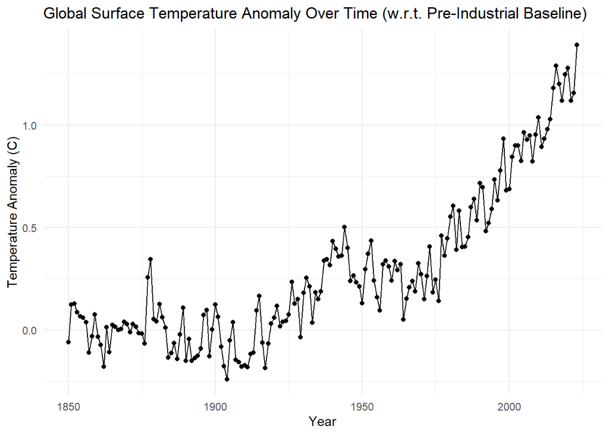

```r
ggplot(hadCRUT_data, aes(x = year, y = anomaly_over_pre_industrial)) +
  geom_line() +
  geom_point() +
  labs(title = "Global Surface Temperature Anomaly Over Time (w.r.t. Pre-Industrial Baseline)",
       x = "Year",
       y = "Temperature Anomaly (C)") +
  theme_minimal()
```

## 1.2.6

Since about 1920, it has both been increasing, as well as accelerating.

### ———- 1.3: How is global temperature related to CO2 levels? ———-

## 1.3.1

The easiest merge key to use would be the year, since it has a standardized progression.

## 1.3.2

To merge using years, we can average all the monthly data within a given year for the Scripps CO2 data.

## 1.3.3

```r
filtered_scripps <- filtered_scripps %>%
  group_by(year) %>%
  summarize(co2 = mean(co2, na.rm = TRUE))
scripps_hadCRUT <- inner_join(filtered_scripps, hadCRUT_data, by = "year")
```

It’s best to use inner join since hadCRUT_data contains data for years that filtered_scripps doesn’t account for.

## 1.3.4

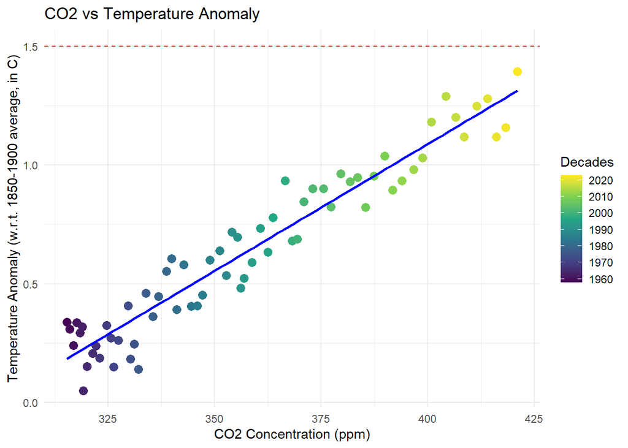

```r
ggplot(scripps_hadCRUT, aes(x = co2, y = anomaly_over_pre_industrial, color = year)) +
  geom_point(size = 3) +
  geom_smooth(method = "lm", se = FALSE, color = "blue") +
  geom_hline(yintercept = 1.5, linetype = "dashed", color = "red") +
  scale_color_viridis_c(name = "Decades", breaks = seq(1850, 2020, by = 10)) +
  labs(title = "CO2 vs Temperature Anomaly",
       x = "CO2 Concentration (ppm)",
       y = "Temperature Anomaly (w.r.t. 1850-1900 average, in C)",
       color = "Decade") +
  theme_minimal()
```

## ———- 2: Global Surface Temperature VS Lower Troposphere Temperature ———-

## 2.1

```r
UAH_data <- read_delim("C:/Users/xuz-t/OneDrive/Documents/INFO_201_Scripts/PS6/data/UAH-lower-troposphere-wide.csv")
UAH_data <- UAH_data[, c("year", "month", "globe")]
head(UAH_data)
```

```
## # A tibble: 6 × 3
##    year month globe
##   <dbl> <dbl> <dbl>
## 1  1978    12 -0.48
## 2  1979     1 -0.48
## 3  1979     2 -0.44
## 4  1979     3 -0.39
## 5  1979     4 -0.41
## 6  1979     5 -0.4
```

## 2.2

```r
UAH_data <- UAH_data %>%
  group_by(year) %>%
  summarise(UAH_anomaly = mean(globe, na.rm = TRUE))
```

## 2.3

```r
hadCRUT_subset <- hadCRUT_data[, -2]
hadCRUT_UAH <- inner_join(UAH_data, hadCRUT_subset, by = "year")
```

## 2.4

The data is currently in wide form.

## 2.5

```r
hadCRUT_UAH <- hadCRUT_UAH %>%
  pivot_longer(cols = c("anomaly_over_pre_industrial", "UAH_anomaly"),
               names_to = "type",
               values_to = "anomaly") %>%
  mutate(type = ifelse(type == "anomaly_over_pre_industrial", "surface", "lower_troposphere"))
head(hadCRUT_UAH)
```

```
## # A tibble: 6 × 4
##    year na.rm type              anomaly
##   <dbl> <lgl> <chr>               <dbl>
## 1  1978 TRUE  surface             0.362
## 2  1978 TRUE  lower_troposphere  -0.48
## 3  1979 TRUE  surface             0.447
## 4  1979 TRUE  lower_troposphere  -0.348
## 5  1980 TRUE  surface             0.553
## 6  1980 TRUE  lower_troposphere  -0.179
```

## 2.6

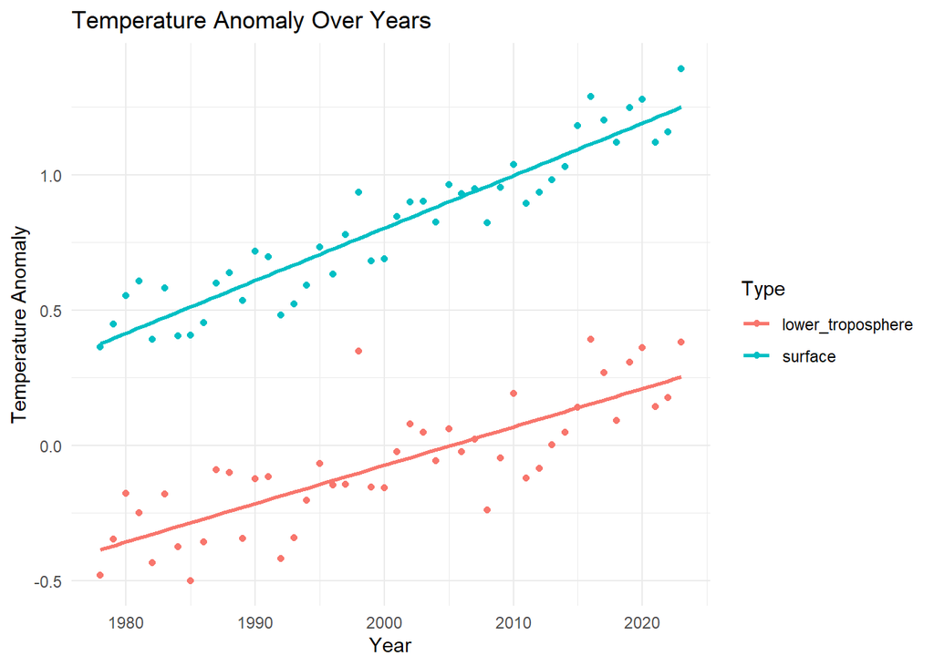

```r
ggplot(hadCRUT_UAH, aes(x = year, y = anomaly, color = type)) +
  geom_point() +
  geom_smooth(method = "lm", se = FALSE) +
  labs(title = "Temperature Anomaly Over Years",
       x = "Year",
       y = "Temperature Anomaly",
       color = "Type") +
  theme_minimal()
```

Surface temperatures (from the hadCRUT dataset) are growing a little faster.